# Reproducible Science

Danny Wong

07 April 2016

# What is Reproducible Science?

- The idea that that data analyses, and more generally, scientific claims, are published with their **data** and **software code** so that others may verify the findings and build upon them.
- When given the same starting point, you can always have the same output. So that if someone else is given the same data, they will get the same results as you.

# This involves

- Writing scripts (software code)
- Commenting within the script about what you’re doing

```r
#Load the data
x <- read.csv("https://raw.githubusercontent.com/datascibc/datastore/master/Breast%20research%20data-%20final1a.csv?token=AIlCxru--M8yReTXWh4hSpKIlf6BaEffks5XD230wA%3D%3D")

#See the 1st 3 column headers
names(x[ , 1:3])
```

```
## [1] "Pt_No"  "Age"    "Gender"
```

```r
#Simple summary stats
summary(x$Age)
```

```
##    Min. 1st Qu.  Median    Mean 3rd Qu.    Max.    NA's
##   29.00   55.00   70.50   66.27   77.00   95.00       4
```

# Traditional workflow

- Work with data in Excel

[figure not shown]

# Traditional workflow

- Import data into statistical software
- Create diagrams/figures on spreadsheet/stats package
- Cut and paste into Microsoft Word or Powerpoint
- Present/publish

# Problems

- Making mistakes whilst manipulating data
- Difficulty discerning what was done when passing data around
- Steps not clearly documented during analysis
- Tedious to go back and re-analyse if changes made

# Benefits of Reproducible Science

- Constant documentation of steps
- Easier to collaborate and share
- Automates steps, imagine n = 1,000,000
- Allows scrutiny of steps and external validation

# R Markdown

- A way of producing a document alongside code
- Integrates workflow into one environment
- Allows saving of changes and collaborating with Git

# R Code and Output

```r
summary(x)
```

```
##      Pt_No            Age            Gender      Radnomisation
##  Min.   : 1.00   Min.   :29.00   Min.   :1.000   Min.   :1.000
##  1st Qu.:16.75   1st Qu.:55.00   1st Qu.:1.000   1st Qu.:1.000
##  Median :32.50   Median :70.50   Median :1.000   Median :1.000
##  Mean   :32.50   Mean   :66.27   Mean   :1.016   Mean   :1.453
##  3rd Qu.:48.25   3rd Qu.:77.00   3rd Qu.:1.000   3rd Qu.:2.000
##  Max.   :64.00   Max.   :95.00   Max.   :2.000   Max.   :2.000
##                  NA's   :4
##   PS_Prior_op        PS_3hrs       PS_12_16hrs     PS_24_28hrs
##  Min.   :0.0000   Min.   :0.000   Min.   :0.000   Min.   :0.00
##  1st Qu.:0.0000   1st Qu.:0.000   1st Qu.:0.000   1st Qu.:0.00
##  Median :0.0000   Median :1.000   Median :1.000   Median :1.00
##  Mean   :0.1905   Mean   :1.125   Mean   :1.406   Mean   :1.25
##  3rd Qu.:0.0000   3rd Qu.:2.000   3rd Qu.:2.000   3rd Qu.:2.00
##  Max.   :3.0000   Max.   :5.000   Max.   :5.000   Max.   :5.00
##  NA's   :1
##     PS_2wks        Mov_12_16hrs    Mov_24_28hrs       Mov_2wks
##  Min.   :0.0000   Min.   :0.000   Min.   :0.0000   Min.   :0.0000
##  1st Qu.:0.0000   1st Qu.:0.000   1st Qu.:0.0000   1st Qu.:0.0000
##  Median :0.0000   Median :1.000   Median :1.0000   Median :0.0000
##  Mean   :0.6275   Mean   :1.078   Mean   :0.9375   Mean   :0.6078
##  3rd Qu.:1.0000   3rd Qu.:2.000   3rd Qu.:1.2500   3rd Qu.:1.0000
##  Max.   :3.0000   Max.   :5.000   Max.   :5.0000   Max.   :4.0000
##  NA's   :13                                        NA's   :13
##  Paracetamol_g    Ibuprofen_mg    Diclofenac_mg     Oromorph_mg
##  Min.   :0.000   Min.   :   0.0   Min.   :  0.00   Min.   :  0.00
##  1st Qu.:4.000   1st Qu.:   0.0   1st Qu.:  0.00   1st Qu.:  0.00
##  Median :7.000   Median :   0.0   Median :  0.00   Median :  0.00
##  Mean   :5.516   Mean   :  62.5   Mean   : 52.73   Mean   : 20.61
##  3rd Qu.:8.000   3rd Qu.:   0.0   3rd Qu.:  0.00   3rd Qu.: 20.00
##  Max.   :8.000   Max.   :1200.0   Max.   :375.00   Max.   :530.00
##
##  Amitryptaline_mg Pregabalin_mg      Days_in_hosp    Reason_hosp_stay
##  Min.   : 0.000   Min.   :  0.000   Min.   : 0.000   Min.   :1.000
##  1st Qu.: 0.000   1st Qu.:  0.000   1st Qu.: 2.000   1st Qu.:1.000
##  Median : 0.000   Median :  0.000   Median : 3.000   Median :1.000
##  Mean   : 1.602   Mean   :  7.812   Mean   : 3.431   Mean   :1.135
##  3rd Qu.: 0.000   3rd Qu.:  0.000   3rd Qu.: 4.000   3rd Qu.:1.000
##  Max.   :40.000   Max.   :300.000   Max.   :10.000   Max.   :3.000
##                                     NA's   :13       NA's   :12
##  Overall_satisfaction
##  Min.   :1.00
##  1st Qu.:3.00
##  Median :3.00
##  Mean   :3.00
##  3rd Qu.:3.25
##  Max.   :4.00
##  NA's   :12
```

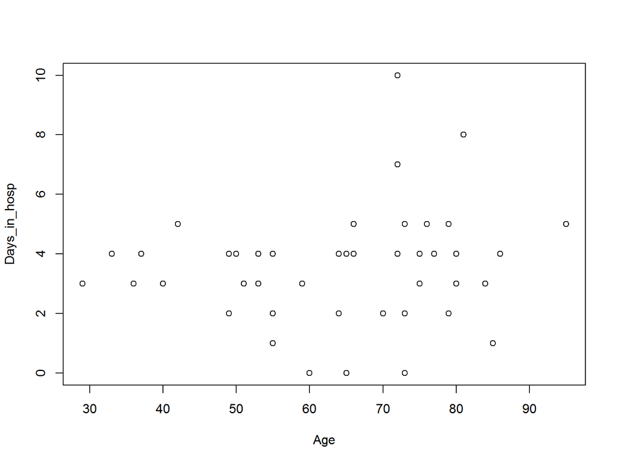

```r
plot(Days_in_hosp ~ Age, data = x)
```

# Going under the hood

[figure not shown]

# Github

[figure not shown]

# R Studio

[figure not shown]

# Example of Reproducible Research Document Outputs

- [Blog post](http://dannyjnwong.github.io/Helipad-Analysis/)
- [.pdf](https://www.dropbox.com/s/g4rvar9g6ybrpeb/DistanceTimeAnalysis.pdf?dl=0)
- [Microsoft Word](https://www.dropbox.com/s/8h583pps6eo47na/DistanceTimeAnalysis.docx?dl=0)